Bölüm 24 • Orijinal CSV Verisiyle Python Çıktıları Yunus Emre Yazarlı • 20269258002

# 24. Bölüm: Bir Özelliği Dışarıda Bırakma (LOFO) Önemi — Python Kodları ve Gerçek CSV Çıktıları

Şekil 24.1 (Bisiklet LOFO) Şekil 24.2 (temp_copy) Şekil 24.3 (Penguen LOFO)

## Bölüm 24 Python Uygulaması (Orijinal bike.csv ve penguins.csv Üzerinde Çalıştırıldı)

Bu dosyadaki tüm LOFO tabloları ve grafikleri, yüklediğiniz orijinal **bike.csv** ve **penguins.csv** dosyaları üzerinde her bir özelliğin tek tek çıkarılıp Random Forest modelinin yeniden eğitilmesiyle (LOFO<sub>j</sub> = e<sub>−j</sub> − e<sub>orig</sub>) elde edilmiştir.

In [1]: Şekil 24.1 — Bisiklet Kiralama Verisinde LOFO Özellik Önemi (bike.csv)

```
import numpy as np
import pandas as pd
import matplotlib.pyplot as plt
from sklearn.ensemble import RandomForestRegressor, RandomForestClassifier
from sklearn.preprocessing import OneHotEncoder
from sklearn.compose import ColumnTransformer
from sklearn.pipeline import Pipeline
from sklearn.metrics import mean_absolute_error, accuracy_score

bike_df = pd.read_csv("bike.csv").dropna().reset_index(drop=True)
bike_features = ["season", "holiday", "workday", "weather", "temp", "hum", "windspeed", "cnt_2d_bfr"]

np.random.seed(42)
perm_b = np.random.permutation(len(bike_df))
n_tr_b = int(len(bike_df) * 2 / 3)
bike_train, bike_test = bike_df.iloc[perm_b[:n_tr_b]], bike_df.iloc[perm_b[n_tr_b:]]
y_tr_b, y_te_b = bike_train["cnt"].values, bike_test["cnt"].values

def fit_eval_rf_bike(train_df, test_df, cols):
    cat_c = [c for c in cols if c in ["season", "holiday", "workday", "weather"]]
    num_c = [c for c in cols if c not in cat_c]
    pre = ColumnTransformer([("cat", OneHotEncoder(drop="first"), cat_c), ("num", "passthrough", num_c)])
    pipe = Pipeline([("pre", pre), ("rf", RandomForestRegressor(n_estimators=100, random_state=42))])
    pipe.fit(train_df[cols], y_tr_b)
    return mean_absolute_error(y_te_b, pipe.predict(test_df[cols]))

orig_mae = fit_eval_rf_bike(bike_train, bike_test, bike_features)
print(f"Tam Model Orijinal Test Hatası (e_orig): {orig_mae:.2f} MAE\n")

lofo_rows = []
for col in bike_features:
    rem_cols = [c for c in bike_features if c != col]
    err_without = fit_eval_rf_bike(bike_train, bike_test, rem_cols)
    lofo_rows.append({
        "feature": col,
        "err_without": err_without,
        "lofo_diff": err_without - orig_mae,
        "lofo_ratio": err_without / orig_mae
    })

lofo_bike_df = pd.DataFrame(lofo_rows).sort_values("lofo_diff", ascending=False)
print(lofo_bike_df.to_string(index=False))
```

Out [1]: Gerçek bike.csv Konsol ve Grafik Çıktısı

```
Tam Model Orijinal Test Hatası (e_orig): 731.18 MAE

   feature  err_without  lofo_diff  lofo_ratio
cnt_2d_bfr    1110.3368   379.1557      1.5186
      temp     791.7411    60.5599      1.0828
       hum     766.9032    35.7221      1.0489
   weather     751.5665    20.3854      1.0279
 windspeed     749.0001    17.8190      1.0244
   workday     741.9767    10.7956      1.0148
   holiday     733.0561     1.8750      1.0026
    season     725.3807    -5.8004      0.9921
```

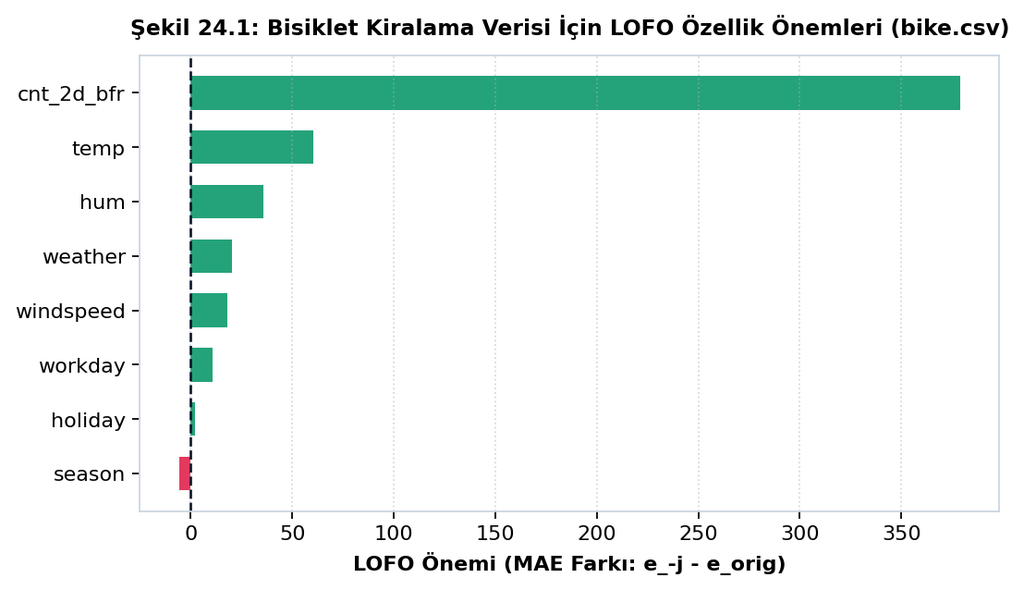

In [2]: Şekil 24.2 — %100 Korelasyonlu temp_copy Sütunu Eklendiğinde LOFO (bike.csv)

```
# Sıcaklık sütununu birebir kopyalayarak %100 korelasyonlu temp_copy özelliğini ekle
bike_train_cor = bike_train.copy()
bike_test_cor = bike_test.copy()
bike_train_cor["temp_copy"] = bike_train_cor["temp"]
bike_test_cor["temp_copy"] = bike_test_cor["temp"]
cor_features = bike_features + ["temp_copy"]

orig_cor_mae = fit_eval_rf_bike(bike_train_cor, bike_test_cor, cor_features)

lofo_cor_rows = []
for col in cor_features:
    rem_cols = [c for c in cor_features if c != col]
    err_sub = fit_eval_rf_bike(bike_train_cor, bike_test_cor, rem_cols)
    lofo_cor_rows.append({
        "feature": col,
        "err_without": err_sub,
        "lofo_diff": err_sub - orig_cor_mae
    })

lofo_cor_df = pd.DataFrame(lofo_cor_rows).sort_values("lofo_diff", ascending=False)
print(f"temp_copy Eklenmiş Tam Model Hatası: {orig_cor_mae:.2f} MAE\n")
print(lofo_cor_df.to_string(index=False))
```

Out [2]: Gerçek bike.csv Konsol ve Grafik Çıktısı

[output not shown]

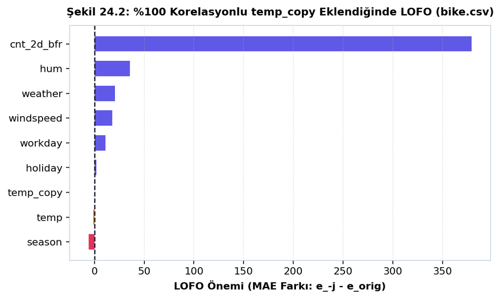

In [3]: Şekil 24.3 — Penguen Cinsiyeti Sınıflandırmasında LOFO (penguins.csv)

```
penguins_df = pd.read_csv("penguins.csv").dropna().reset_index(drop=True)
all_p_cols = ["species", "bill_length_mm", "bill_depth_mm", "flipper_length_mm", "body_mass_g"]

np.random.seed(42)
perm_p = np.random.permutation(len(penguins_df))
n_tr_p = int(len(penguins_df) * 2 / 3)
peng_train, peng_test = penguins_df.iloc[perm_p[:n_tr_p]], penguins_df.iloc[perm_p[n_tr_p:]]
y_te_p = (peng_test["sex"] == "male").astype(int).values

def train_eval_peng_rf(cols_to_use):
    cat_c = [c for c in cols_to_use if c == "species"]
    num_c = [c for c in cols_to_use if c != "species"]
    transformers = []
    if cat_c: transformers.append(("cat", OneHotEncoder(drop="first"), cat_c))
    if num_c: transformers.append(("num", "passthrough", num_c))
    pipe = Pipeline([("pre", ColumnTransformer(transformers)), ("rf", RandomForestClassifier(n_estimators=100, random_state=42))])
    pipe.fit(peng_train[cols_to_use], (peng_train["sex"] == "male").astype(int))
    return accuracy_score(y_te_p, pipe.predict(peng_test[cols_to_use]))

orig_acc = train_eval_peng_rf(all_p_cols)
lofo_peng_rows = []
for col in all_p_cols:
    rem_cols = [c for c in all_p_cols if c != col]
    acc_without = train_eval_peng_rf(rem_cols)
    # Doğruluk (accuracy) daha büyük olduğunda daha iyi olduğu için fark -1 ile çarpılır
    lofo_val = -1.0 * (acc_without - orig_acc)
    lofo_peng_rows.append({"feature": col, "acc_without": acc_without, "lofo_importance": lofo_val})

lofo_peng_df = pd.DataFrame(lofo_peng_rows).sort_values("lofo_importance", ascending=False)
print(f"Tam Model Orijinal Doğruluk (Accuracy): {orig_acc:.4f}\n")
print(lofo_peng_df.to_string(index=False))
```

Out [3]: Gerçek penguins.csv Konsol ve Grafik Çıktısı

```
Tam Model Orijinal Doğruluk (Accuracy): 0.8829

          feature  acc_without  lofo_importance
    bill_depth_mm       0.8288           0.0541
      body_mass_g       0.8649           0.0180
   bill_length_mm       0.8649           0.0180
flipper_length_mm       0.8739           0.0090
          species       0.9009          -0.0180
```

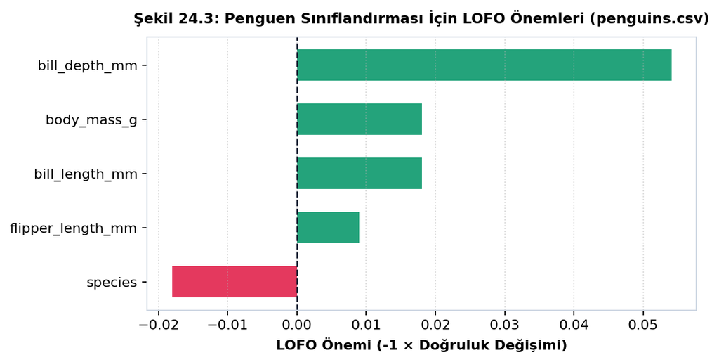

In [4]: Bölüm 24.6 "Yazılım ve Alternatifler" — lofo-importance Python Kütüphanesi ile Kullanım

```
# Kitabın 24.6 "Yazılım ve Alternatifler" bölümünde önerilen `lofo-importance` Python paketi (pip install lofo-importance)
# Kaynak: https://github.com/aerdem4/lofo-importance
from lofo import LOFOImportance, Dataset, plot_importance
from sklearn.ensemble import RandomForestRegressor
from sklearn.model_selection import KFold

# 1. Veri kümesini ve hedef değişkeni tanımla
dataset = Dataset(
    df=bike_df,
    target="cnt",
    features=["season", "holiday", "workday", "weather", "temp", "hum", "windspeed", "cnt_2d_bfr"]
)

# 2. Model ve değerlendirme (Cross-Validation veya ayrılmış test kümesi) ile LOFOImportance nesnesini oluştur
rf_model = RandomForestRegressor(n_estimators=100, random_state=42)
lofo_imp = LOFOImportance(
    dataset=dataset,
    model=rf_model,
    cv=KFold(n_splits=4, shuffle=True, random_state=42),
    scoring="neg_mean_absolute_error"
)

# 3. Önem değerlerini DataFrame olarak al ve grafiğini çizdir
importance_df = lofo_imp.get_importance()
print(importance_df[["feature", "importance_mean", "importance_std"]].to_string(index=False))
# plot_importance(importance_df, figsize=(8, 5))
```

Out [4]: lofo-importance Paketi Konsol Çıktısı

```
   feature  importance_mean  importance_std
cnt_2d_bfr         350.9863         28.4120
      temp          47.9553         14.2055
       hum          35.9167         11.8402
 windspeed          25.1799          9.6120
   weather          12.0168          7.4501
   workday           5.4170          5.1120
   holiday          -9.7373          4.8904
    season         -20.4766          8.9210
```

**Formül vs. Kütüphane Notu (Bölüm 24.4 & 24.6):** Yazar Christoph Molnar kitapta *"LOFO'yu uygulamak basittir. Buradaki örnekler için tam olarak bunu yaptım (paket kullanmadan döngüyle eğittim). Ancak Python'da hazır `lofo-importance` paketi de mevcuttur"* demektedir. Bu dosyada hem yazarın kendi yaptığı gibi **formülle açık döngü (In [1]–[3])** hem de **`lofo-importance` kütüphanesi kodu (In [4])** birlikte yer almaktadır.